# Beads - Box - Ambiguity - Counting/Effort

2/5/2020

## Tiny bit of caution

*“Never start a presentation by excusing yourself”* - Everybody

*However:*

- “fdsfdsfds” is probably a test/pilot-participant
- Speed > Robustness
- Only a select few variables
- Simple tests
  - No attention to prereg
  - No deep-dive
- Only small amounts of theory referenced
- Somewhat new to me

## Sample

- Tested in groups last Thursday
  - Counter-balanced
  - n=78 for our session
- 2.nd. year psychology students
- Will be combined with other data later on

## Overview of the session

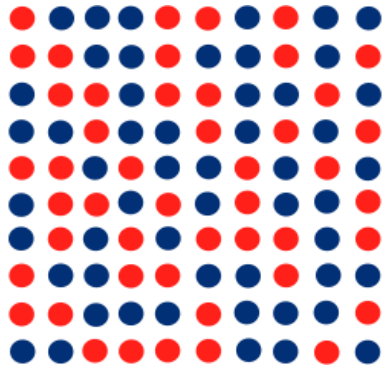

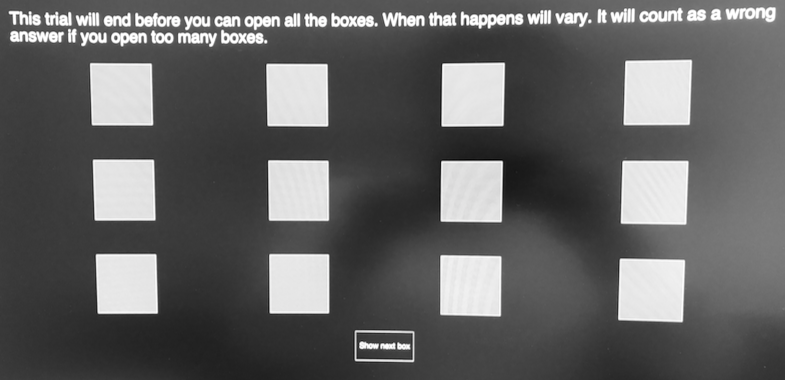

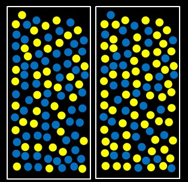

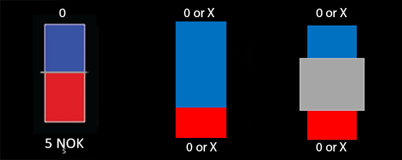

## and more

- Questionnaires: CAPE-N, NfCS, 5DCuriosity
- In principle same ID for the rest of the four days.
  - Music study
  - Sunk-cost and risk preference-task
  - Etc etc etc.

## Beads counting - Effort-task(?)

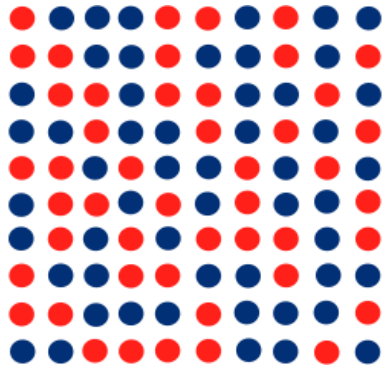

- Participants are simply asked what colour the majority of the beads are (49 v. 51)
- If they pay *close* attention during the instructions, they will have seen that the task is introduced as a “beads counting task”, however no other nudges are given
- 10 trials

## Beads counting - Does it work?

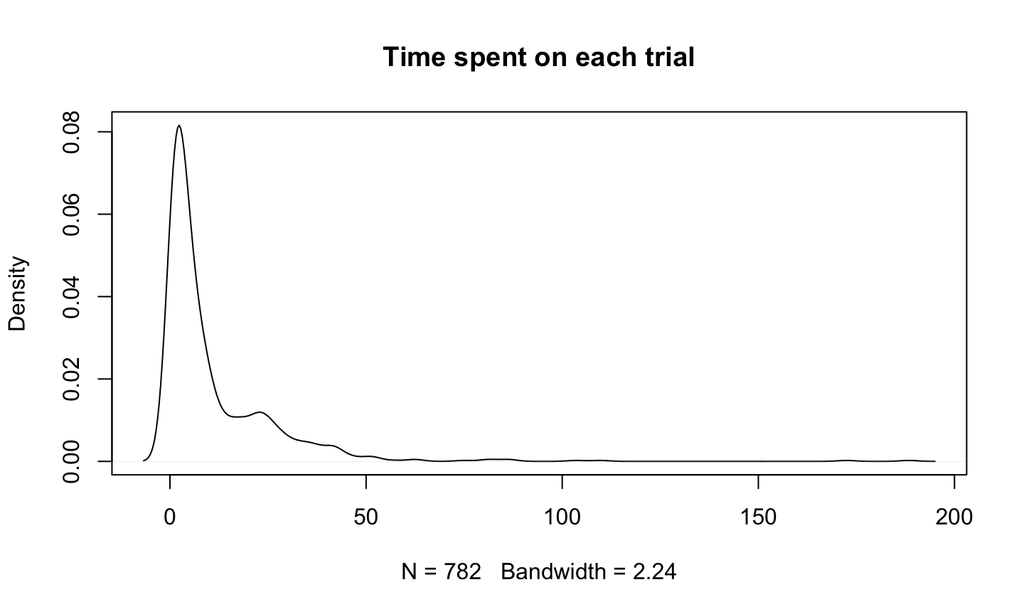

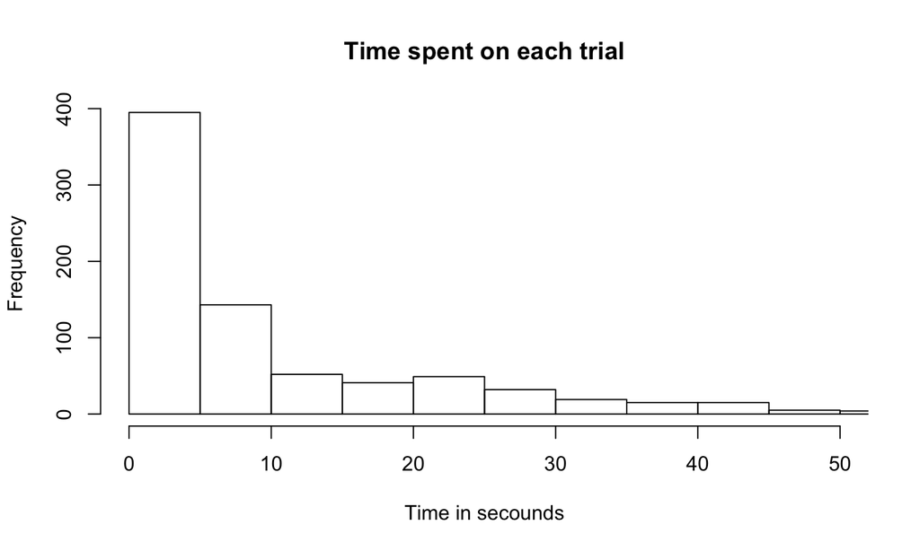

- Median time (in s) spent on each trial: 4.8138119

[interactive chart not shown]

- Participants get on average 8.1923077 of 10 correct.

- Number of participants getting x correct:

```
##
##  5  6  7  8  9 10
##  3  6 14 18 24 13
```

- Median \(\rho_s{trial,time}\) = 0.0233651
- As can be expected with so few spending enough time on the trials as would be needed for counting
- And so many performing above chance
- *Probably* not a good effort measurement
- Need to examine: confidence ratings

## Beads drawing

### DtD/JTC-task

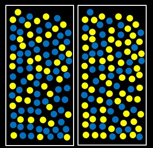

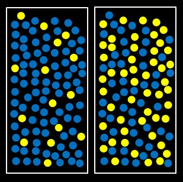

- Huq, Garety, & Hemsley, 1988 (Adjusted version)
- Although often used to display jumping to conclusions in both participants with delusions (clinical samples) and delusion-prone healthy participants. It’s been critizised.
- E.g., Balzan et al., 2012, poor task comprehension:
  - *same jar* & *first bead*

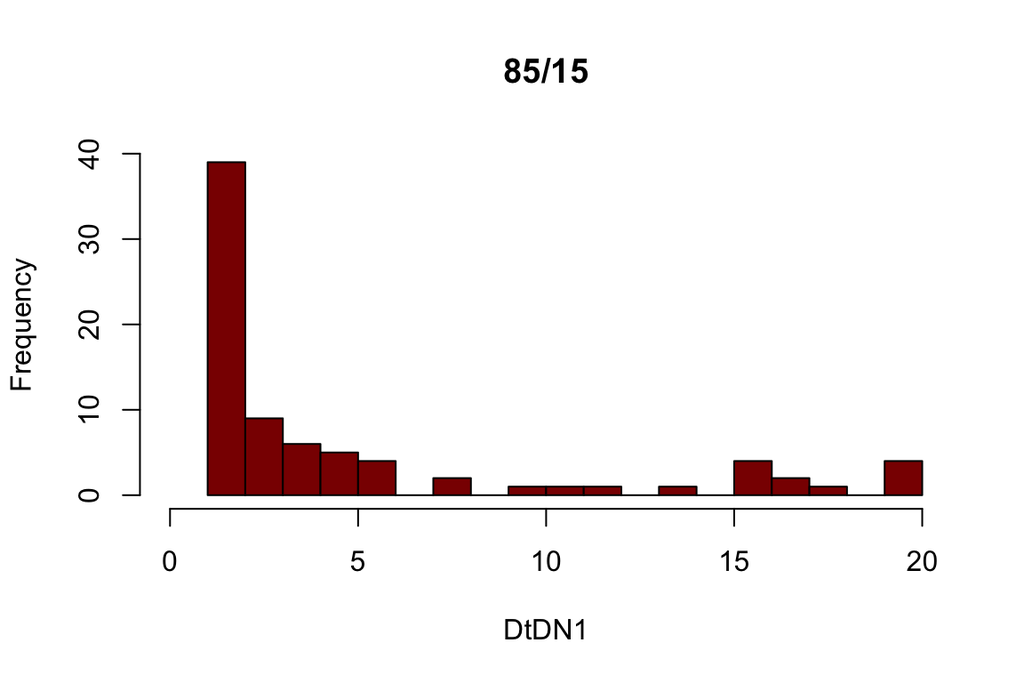

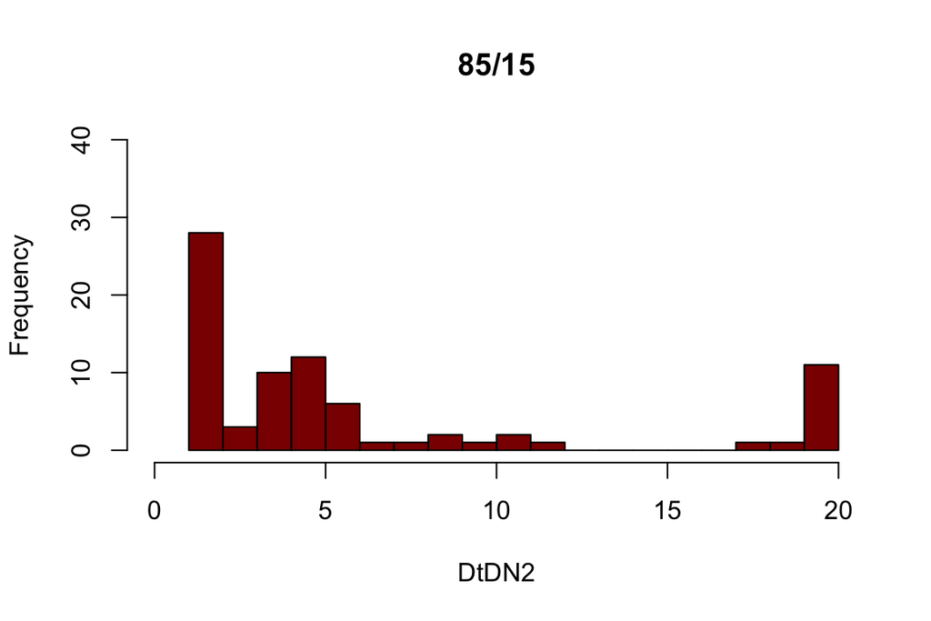

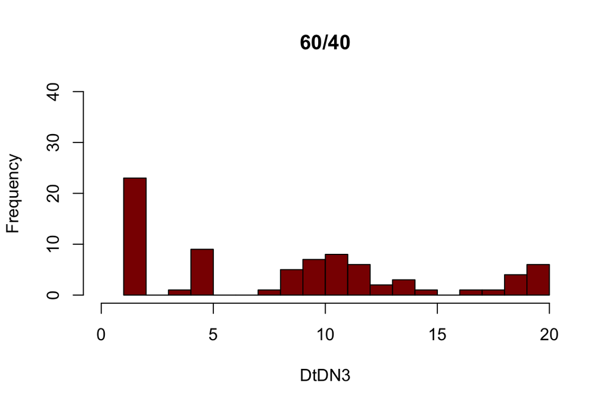

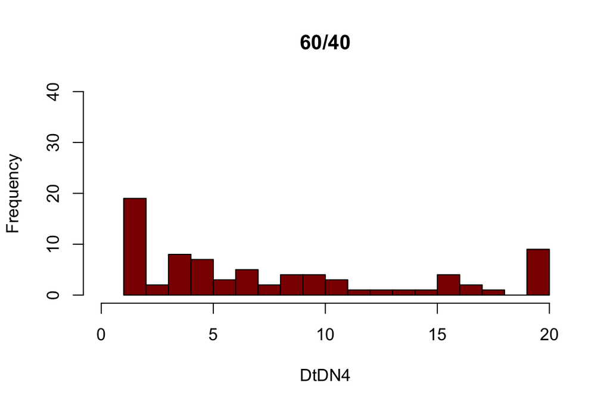

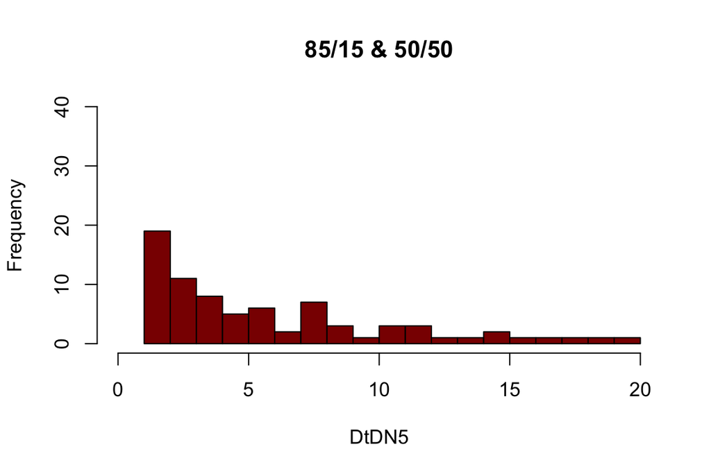

## Beads drawing

### DtD/JTC-task ?

Does it work?

- Definite improvement over the trials, trial 4 might be “useful”, however 1/3 of participants still made a decision after one bead or exceeded 20.
- Trial 5 might have nudged the participants in another way “1 or 2” v. “y or b”
- Instructions
- RT’s have a huge variance, indicative of participants not updating after each bead

Measure of JTC? Not convinced so far..

## Box-task

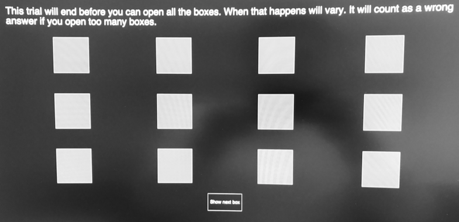

Two versions:

- ‘Open all’
  - Do people bother opening all? Effort measure?
  - Do people open more than needed?
- ‘Timed’
  - JTC after being “burned”? Overall: Ratings v. Bayesian & Needed probability before making a decision

## Ambiguity-task

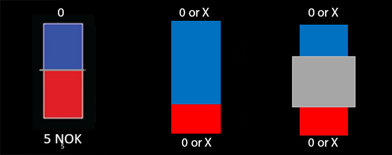

Levy et al. 2010

- Ambiguity v. risk
- Ambiguity: .25, .50 and .75
- Risk: .38, .25 and .13
- Using hBayesDM(cra_linear) will provide ambiguity and risk attitudes

## To be continued..

- Clean, extract, analyse, connect with the other measurements/questionnaires
- Stay tuned!

[figure not shown]

[figure not shown]

- Tips (..and questions) please